# (Loan Data Analysis)

## Preliminary Wrangling

> This data set contains 113,937 loans with 81 variables on each loan, including loan amount, borrower rate (or interest rate), current loan status, borrower income, and many others.

```python
# import all packages and set plots to be embedded inline
import numpy as np
import pandas as pd
import matplotlib.pyplot as plt
import seaborn as sb

%matplotlib inline
```

> Load in your dataset and describe its properties through the questions below. Try and motivate your exploration goals through this section.

```python
#Reading the CSV file and visually exploring it :
df = pd.read_csv('LoanData.csv')
df.head()
```

|  | ListingKey | ListingNumber | ListingCreationDate | CreditGrade | Term | LoanStatus | ClosedDate | BorrowerAPR | BorrowerRate | LenderYield | ... | LP_ServiceFees | LP_CollectionFees | LP_GrossPrincipalLoss | LP_NetPrincipalLoss | LP_NonPrincipalRecoverypayments | PercentFunded | Recommendations | InvestmentFromFriendsCount | InvestmentFromFriendsAmount | Investors |
| --- | --- | --- | --- | --- | --- | --- | --- | --- | --- | --- | --- | --- | --- | --- | --- | --- | --- | --- | --- | --- | --- |
| 0 | 1021339766868145413AB3B | 193129 | 2007-08-26 19:09:29.263000000 | C | 36 | Completed | 2009-08-14 00:00:00 | 0.16516 | 0.1580 | 0.1380 | ... | -133.18 | 0.0 | 0.0 | 0.0 | 0.0 | 1.0 | 0 | 0 | 0.0 | 258 |
| 1 | 10273602499503308B223C1 | 1209647 | 2014-02-27 08:28:07.900000000 | NaN | 36 | Current | NaN | 0.12016 | 0.0920 | 0.0820 | ... | 0.00 | 0.0 | 0.0 | 0.0 | 0.0 | 1.0 | 0 | 0 | 0.0 | 1 |
| 2 | 0EE9337825851032864889A | 81716 | 2007-01-05 15:00:47.090000000 | HR | 36 | Completed | 2009-12-17 00:00:00 | 0.28269 | 0.2750 | 0.2400 | ... | -24.20 | 0.0 | 0.0 | 0.0 | 0.0 | 1.0 | 0 | 0 | 0.0 | 41 |
| 3 | 0EF5356002482715299901A | 658116 | 2012-10-22 11:02:35.010000000 | NaN | 36 | Current | NaN | 0.12528 | 0.0974 | 0.0874 | ... | -108.01 | 0.0 | 0.0 | 0.0 | 0.0 | 1.0 | 0 | 0 | 0.0 | 158 |
| 4 | 0F023589499656230C5E3E2 | 909464 | 2013-09-14 18:38:39.097000000 | NaN | 36 | Current | NaN | 0.24614 | 0.2085 | 0.1985 | ... | -60.27 | 0.0 | 0.0 | 0.0 | 0.0 | 1.0 | 0 | 0 | 0.0 | 20 |

5 rows × 81 columns

### What is/are the main feature(s) of interest in your dataset?

> Is bigger income range corelated with the employment status ?

### What features in the dataset do you think will help support your investigation into your feature(s) of interest?

> loan status, employment status,and APR.

## Univariate Exploration

> In this section, investigate distributions of individual variables. If you see unusual points or outliers, take a deeper look to clean things up and prepare yourself to look at relationships between variables.

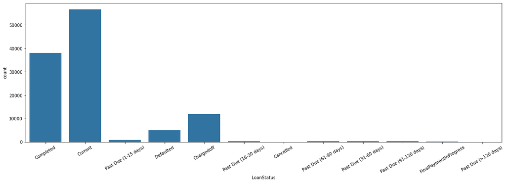

```python
# Chosing a color :
base_col = sb.color_palette()[0]
# Plotting 'Loan Status' as it is a Categorical Vriable, we use countplot in seaborn.
# code :
plt.figure(figsize = [20,6])
plt.xticks(rotation = 30)
sb.countplot(data = df , x = 'LoanStatus', color = base_col);
```

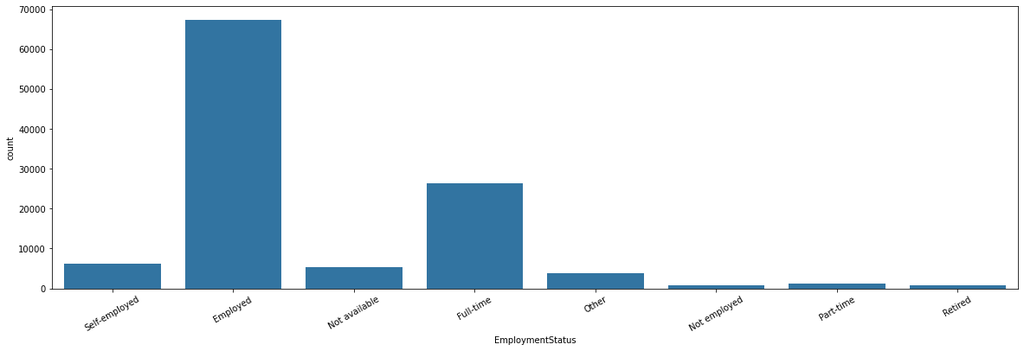

```python
# Chosing a color :
base_col = sb.color_palette()[0]
# Plotting 'Loan Status' as it is a Categorical Vriable, we use countplot in seaborn.
# code :
plt.figure(figsize = [20,6])
plt.xticks(rotation = 30)
sb.countplot(data = df , x = 'EmploymentStatus', color = base_col);
```

we notice that most of people are employed, some of them are occupying a full time job and very few are retired.

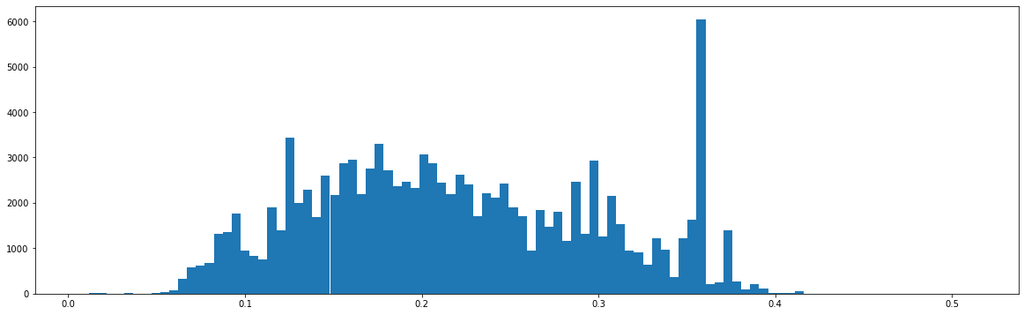

```python
#Borrower APR distribution:

plt.figure(figsize = [20,6])
plt.hist(data = df , x = 'BorrowerAPR',bins = 100);
```

The distribution of the borrower's Annual Percentage Rate (APR) for the loan seemes normally distributed about .2 percent ,with a peak between the value of .3 and .4

### Discuss the distribution(s) of your variable(s) of interest. Were there any unusual points? Did you need to perform any transformations?

> The values are easy to read and i didn't need to perform any kind of transformation.

### Of the features you investigated, were there any unusual distributions? Did you perform any operations on the data to tidy, adjust, or change the form of the data? If so, why did you do this?

> No, the data were easy to read in visuals.

## Bivariate Exploration

> In this section, investigate relationships between pairs of variables in your data. Make sure the variables that you cover here have been introduced in some fashion in the previous section (univariate exploration).

### 1- Quantitative - Quantitative Corelation Using Scatter Plot :

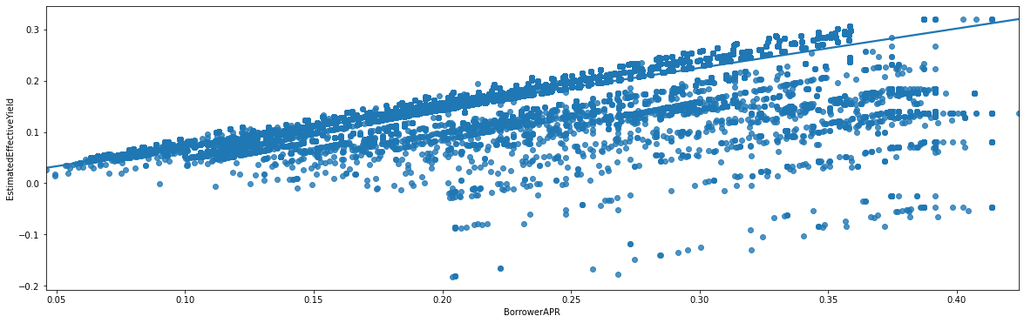

```python
# BorrowerAPR and EstimatedEffectiveYield
plt.figure(figsize = [20,6])
sb.regplot(data = df, x = 'BorrowerAPR' , y = 'EstimatedEffectiveYield',);
```

We notice that the Estimated Effective Yield is positively corelatted to the Borrower APR

### 2- Quantitative - Qualititative Corelation Using Violin and Box Plot :

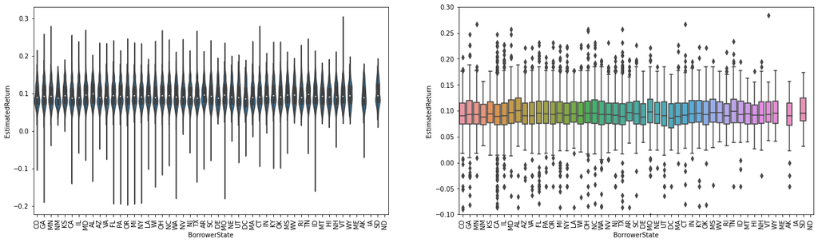

```python
# Borrower state Status and Return:
plt.figure(figsize = [22, 6])
base_color = sb.color_palette()[0]
# LEFT plot: violin plot
plt.subplot(1, 2, 1)
#Let's return the axes object
ax1 = sb.violinplot(data=df, x = 'BorrowerState' , y = 'EstimatedReturn', color=base_color, innner='quartile')
plt.xticks(rotation=90);

# RIGHT plot: box plot
plt.subplot(1, 2, 2)
sb.boxplot(data = df, x = 'BorrowerState' , y = 'EstimatedReturn',)
plt.xticks(rotation = 90)
plt.ylim(-.1,.3) ;
```

It seems that the return of most of loans is around .1 with some outlaiers

### 3- Qualititative - Qualititative Corelation Using Clusterred barcharts :

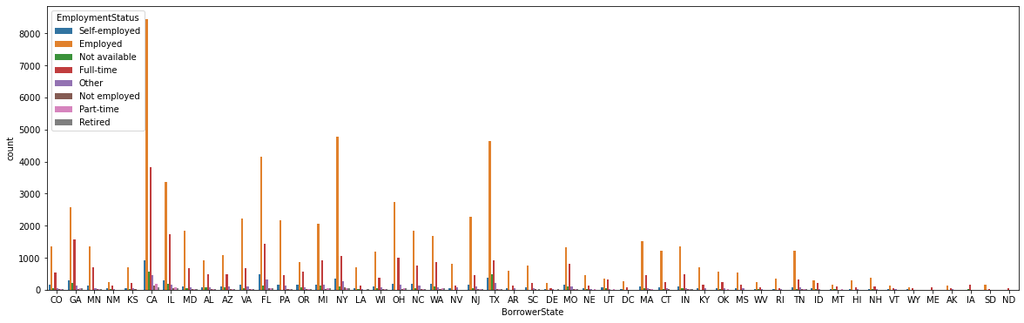

```python
# Borrower state Status and Borrower employment status:
plt.figure(figsize = [20,6])
sb.countplot(data = df, x = 'BorrowerState', hue = 'EmploymentStatus');
```

As we see, the most employed borrowers are from CA and the most employment status in the same state is employed

### Talk about some of the relationships you observed in this part of the investigation. How did the feature(s) of interest vary with other features in the dataset?

> Most of the data is near to each other. Variation in these economic data is dependent on the situation in the contry.

### Did you observe any interesting relationships between the other features (not the main feature(s) of interest)?

> The dataset is too big. I'm sure if we gigged deeper we'll find more interisting things

## Multivariate Exploration

> Create plots of three or more variables to investigate your data even further. Make sure that your investigations are justified, and follow from your work in the previous sections.

#### 1- Numeric Third variable Using Color Palette :

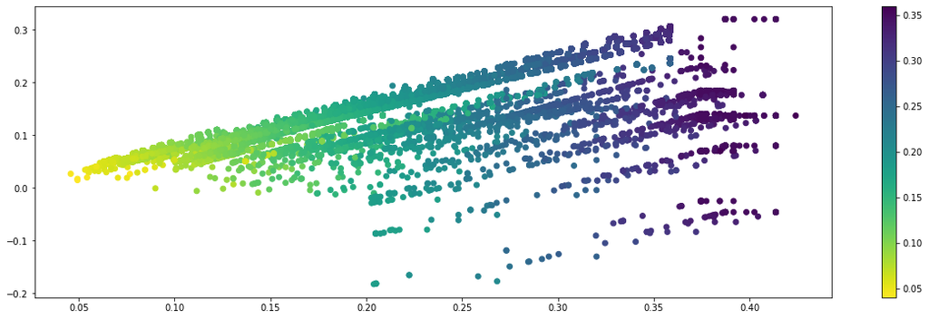

```python
# BorrowerAPR and EstimatedEffectiveYield and Borrower Rate as Third vsriable :
plt.figure(figsize = [20,6])
plt.scatter(data = df,  x = 'BorrowerAPR', y = 'EstimatedEffectiveYield' , c = 'BorrowerRate' , cmap = 'viridis_r');
plt.colorbar();
```

The Borrower rate is corelated to the APR and the Estimated Effective Yield.

As the APR and Yield increases, Rate increases too.

#### 2- Faceting in Multivariate Visualization:

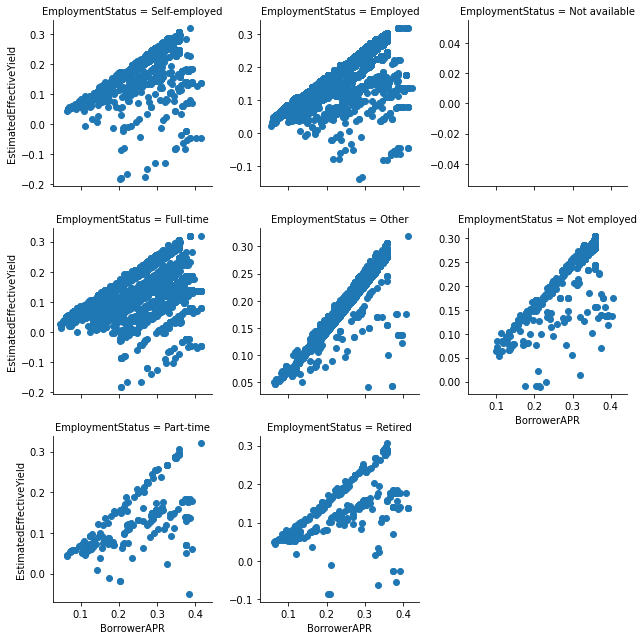

```python
#Faceting in Multi variable :
bin_edges = np.arange(12, 58+2, 2)
g = sb.FacetGrid(data = df, col = 'EmploymentStatus', col_wrap=3, sharey=False, margin_titles = True)
g.map(plt.scatter,'BorrowerAPR','EstimatedEffectiveYield');
```

The difference is slight and gives no signal on how employmnt statusaffectour variables.

### Talk about some of the relationships you observed in this part of the investigation. Were there features that strengthened each other in terms of looking at your feature(s) of interest?

> Some data are helpfulin finding indughts of the big picture but some other don't add much when we dig deeper. I thinkthis dataset needs more infestigation by some specialest in economic studies.

### Were there any interesting or surprising interactions between features?

> I think unemployed people data are intersting because we need to know how do they get to pay for their loans.